# Zombie Battle Royale – Workshop-Handout

# Stil-Vorlage – immer mit in den Gemini-Prompt!

Damit alle generierten Bilder zusammenpassen, **muss der passende Block immer ans Ende des Prompts** — nie weglassen.

## 🖼️ Für Hintergrundbilder (Szenen-Bilder)

```
STYLE: Stylized painterly cartoon illustration, slightly brushy textures, high contrast,
clear silhouettes, dark but vibrant palette — dominated by mossy greens, moody greys,
warm amber accents. Inspired by LucasArts adventure game backgrounds, Tim Burton,
Goosebumps book covers, Hotel Transylvania. Spooky but kid-friendly (age 10–14).

ATMOSPHERE: Overcast sky with a sickly yellow-green tint visible through the skylights
and windows. Low ground fog drifting between the tables. Long diagonal shadows.
Dried leaves and torn paper pages swirling in cold wind through the hall.
Subtle volumetric light rays cutting through the skylights.

TECHNICAL: 16:9 aspect ratio, 1280x720 resolution, sharp focus on foreground,
slight atmospheric depth-of-field on background.
No text, no speech bubbles, no UI overlays, no watermarks. No gore.
```

## 🧩 Für Sprites (einzelne Figuren / Objekte, transparenter Hintergrund)

```
STYLE: Stylized painterly cartoon illustration, slightly brushy textures, high contrast,
clear silhouettes, dark but vibrant palette — dominated by mossy greens, moody greys,
warm amber accents. Inspired by LucasArts adventure game backgrounds, Tim Burton,
Goosebumps book covers, Hotel Transylvania. Spooky but kid-friendly (age 10–14).

TECHNICAL: Transparent background, PNG with alpha channel, object centered on canvas,
no drop shadow, no cast ground shadow, no floor, no background elements.
No text, no watermarks. No gore.
```

## Beispiel: vollständiger Prompt

**Hintergrundbild:** > Classroom of a German school seen from a top-down angle, overrun by zombies. > Desks and chairs scattered, backpacks on the floor, a door at the far end. > > STYLE: Stylized painterly cartoon illustration, slightly brushy textures, high contrast, clear silhouettes, dark but vibrant palette — dominated by mossy greens, moody greys, warm amber accents. Inspired by LucasArts adventure game backgrounds, Tim Burton, Goosebumps book covers, Hotel Transylvania. Spooky but kid-friendly (age 10–14). > > ATMOSPHERE: Overcast sky with a sickly yellow-green tint visible through the skylights and windows. Low ground fog drifting between the tables. Long diagonal shadows. Dried leaves and torn paper pages swirling in cold wind through the hall. Subtle volumetric light rays cutting through the skylights. > > TECHNICAL: 16:9 aspect ratio, 1280x720 resolution, sharp focus on foreground, slight atmospheric depth-of-field on background. No text, no speech bubbles, no UI overlays, no watermarks. No gore.

> **Tipp:** Wenn Gemini den Stil ignoriert, schreibe ganz an den Anfang: `"In the exact style of a LucasArts adventure game background:"`

# Station 01 – Schulhof (Start)

**Deine Aufgabe:** Ankommen, orientieren — und dann den ersten eigenen Ton ins Spiel bringen.

## 1.1 🗂️ Projektstruktur kennenlernen

Öffne den Projektordner `zombie-battle-royale` in deinem Editor und schau dir kurz diese Dateien an:

| Datei | Was sie macht |
| --- | --- |
| `game/index.html` | Startet das Spiel, lädt alle Programmteile und Spiele |
| `docs/01_schulhof/assets/` | Hier liegt die Beschreibung der Aufgabe und ggf Arbeitsmaterial |
| `game/01_schulhof/assets/` | Fertige generierte Bilder und Sounds für diese Station, um sie im Spiel zu benutzen |

Starte das Spiel einmal im Browser — einfach `game/index.html` öffnen. Du siehst den Schulhof-Bildschirm.

## 1.2 🎙️ Ton anhören

Der Sprecher-Intro-Sound ist schon fertig aufgenommen — hör ihn dir kurz an:

> 🔊 `game/01_schulhof/assets/intro_voice.mp3`

```
Ein ganz normaler Schultag — bis der erste Schrei durch den Flur hallt.

Innerhalb von Minuten ist die Schule voll. Überall stolpern Zombies herum —
der Mathe-Lehrer, der Hausmeister, sogar deine Banknachbarin. Du rennst auf
den Schulhof. Dein Baseballschläger liegt im Gebüsch, zum Glück!

Die Mensa hat solide Türen. Vielleicht ein Zufluchtsort.
```

## 1.3 🤖 Ton einbauen mit Claude Code (KI für Programmierung)

Öffne Claude Code im Projektordner `zombie-battle-royale` und paste diesen Prompt:

```
In der Datei game/scenes.js gibt es eine Szene mit id "start".
Füge dort zwei Felder hinzu:

  audio: "01_schulhof/assets/intro_voice.mp3",
  startOverlay: true,

Das audio-Feld sorgt dafür, dass die Engine den Ton automatisch abspielt
und einen Lautsprecher-Button neben dem Text zeigt.
Das startOverlay-Feld blendet beim ersten Aufruf einen "Spiel starten"-Button
mittig über das Schulhof-Bild — erst beim Klick startet der Ton (notwendig,
damit der Browser den Sound zulässt).
```

Starte das Spiel neu im Browser — beim ersten Öffnen erscheint der Start-Button, Klick startet den Sound. ✅

# Station 02 – Mensa (Minispiel: Teller werfen)

**Deine Aufgabe:** Das Teller-Wurf-Minispiel bauen — mit Claude Code. Kein Programmieren von Hand.

> ✅ **Bereits vorhanden:** - Start-Bildschirmfoto: `game/02_mensa/assets/mensa_intro.png` - Kampf-Hintergrundbild: `game/02_mensa/assets/mensa_kampf.png`

> Schau sie dir kurz an — gefallen sie dir? Dann brauchen wir jetzt einen Sprecher für unsere Texte.

## 2.1 🎙️ Ton vor dem Minispiel – mit ElevenLabs (KI für Umwandlung von Text in Sprache) vertonen

Bevor das Minispiel startet, soll ein Sprecher die Szene einleiten. Der Basistext:

```
Die Mensa. Überall Zombies.
Aber da — ein Stapel Teller.
```

ElevenLabs **v3** versteht **Audio-Tags** in eckigen Klammern direkt im Text — sie steuern, wie die Stimme klingt (z. B. flüsternd, schreiend, keuchend).

Geh auf elevenlabs.io, stelle **Model = v3** ein, wähle die Stimme **„Commander Brake – Strict & Dominant”** und kopier diesen Text 1:1 rein:

```
[gasp] [panicked] Die Mensa — überall Zombies!
[pause] [whispering] Aber da... ein Stapel Teller.
```

Speichere die generierte Datei als `game/02_mensa/assets/mensa_voice_intro.mp3`.

Dann lass Claude Code den Ton einbauen im Projektordner `zombie-battle-royale`. Paste dort diesen Prompt::

```
In game/scenes.js bei der Szene "mensa_intro":
Füge ein audio-Feld hinzu mit Wert "02_mensa/assets/mensa_voice_intro.mp3".
Die Engine spielt das Audio dann automatisch beim ersten Aufruf ab und zeigt
einen Lautsprecher-Button neben dem Text.
```

## 2.2 🤖 Minispiel bauen mit Claude Code

Öffne Claude Code im Projektordner `zombie-battle-royale` und paste diesen Prompt:

```
Ich baue ein Browser-Spiel (Vanilla JS, kein Framework).
Erstelle die Datei game/02_mensa/teller.js mit der Funktion startTellerWerfen(onWin, onLose).

Das Minispiel läuft im Element #combat-area (position: relative, 1280x720px).
Hintergrundbild: renderSceneImage("02_mensa/assets/mensa_kampf.png") — diese Funktion existiert schon in engine.js.

Wichtig zur Perspektive: Das Hintergrundbild (mensa_kampf.png) zeigt die Mensa
aus Alex' Blick — Tischreihen fluchten in einen **Fluchtpunkt in der Bildmitte**
(ungefähr horizontal zentriert, vertikal bei ca. 40% Höhe = die hintere Wand mit
den Fenstern). Die Zombies müssen sich in dieser Perspektive bewegen, sonst
wirkt es, als würden sie in der Luft schweben.

Spielmechanik:
- Alex-Sprite (ove_mensa.png aus 02_mensa/assets/) steht am unteren Rand (Vordergrund),
  bewegt sich mit A/D oder Pfeiltasten links/rechts.
- Mit Leertaste wirft Alex einen Plastikteller in Richtung Fluchtpunkt — dargestellt
  als reiner weißer Kreis (div, ca. 36px, `background: white`, `border-radius: 50%`,
  dezenter `box-shadow` für Plastik-Look). Der Teller fliegt geradeaus nach oben und
  wird mit zunehmender Distanz **kleiner** (Scale abnehmend von 1.0 auf ca. 0.3),
  passend zur Perspektive.
- Zombies spawnen **klein am Fluchtpunkt** (nahe der Bildmitte, ca. y=40% Höhe,
  x leicht gestreut zwischen den Tischreihen) und laufen auf Alex zu —
  also in Richtung Vordergrund. Dabei:
   - ihre y-Position wandert Richtung unterer Rand,
   - ihre x-Position fächert sich leicht nach außen auf (zur jeweils nächsten
     Tischreihen-Gasse), damit sie den Fluchtlinien folgen statt in der Mitte
     zu drängen,
   - ihre **Größe (Scale) wächst** mit der Distanz zur Kamera (z. B. von 0.25
     am Fluchtpunkt auf 1.2 am Vordergrund).
- Bilder aus 02_mensa/assets/: zombie_deutschlehrerin.png, zombie_hausmeister.png,
  zombie_koechin.png, zombie_mathelehrer.png, zombie_schueler.png,
  zombie_schuelerin.png (pro Spawn zufällig einen auswählen).
- Trifft ein Teller einen Zombie → beide verschwinden, Punkt +1. Kollision muss die
  aktuelle skalierte Größe des Zombies berücksichtigen (kein fester Hit-Radius).
- Erreicht ein Zombie den unteren Rand (Alex ist getroffen) → loseHeart(1) aufrufen
  (existiert in engine.js), dann Zombie entfernen.
- 3 Wellen: Welle 1 = 3 Zombies langsam, Welle 2 = 5 Zombies schneller, Welle 3 = 7
  Zombies mit leichtem Zickzack zwischen den Gassen.
- Alle 3 Wellen geschafft → cleanup, onWin() aufrufen.
- gameState.hearts === 0 → cleanup, onLose() aufrufen.

Schau dir game/05_basketballplatz/basketball.js als Muster an — gleiche Struktur: combat-area befüllen, Game-Loop mit requestAnimationFrame, Keyboard-Listener registrieren und am Ende wieder entfernen.

Danach füge in game/index.html vor scenes.js den Tag
<script src="02_mensa/teller.js"></script>
ein.

Ersetze außerdem in game/scenes.js bei der mensa_intro-Szene den placeholderMinigame-Aufruf durch:
startTellerWerfen(() => showScene("mensa_sieg"), () => showScene("mensa_fail"))
```

## 2.3 🎨 Mensa-Siegbild mit Gemini generieren

Nach dem gewonnenen Minispiel brauchen wir einen **Abschlussbildschirm** — Alex hat’s durch die Hintertür der Mensa geschafft und steht im Foyer.

> 📸 **Referenzfoto:** `docs/02_mensa/mensa_ausgang.jpg` — echtes Foto des Foyer-Bereichs hinter der Mensa. **Lade es mit in Gemini hoch**, damit der Schauplatz wiedererkennbar bleibt (hohe Glasfront mit Bäumen dahinter, dunkler quaderförmiger Metallkasten mit Durchgang rechts, Galerie-Brüstung mit vertikalen Streben oben, helle glatte Bodenfliesen, lineare Deckenleuchten).

> 📋 **Stil-Vorlage:** Die fett markierten Stil-Zeilen in jedem Prompt stammen aus `docs/00_stil-vorlage.md` — nie weglassen, damit alle Bilder zusammenpassen.

```
In the exact style of a LucasArts adventure game background:

Interior of a modern German school entrance foyer, just behind the cafeteria's
back door — based exactly on the attached reference photo. Match the architecture:
- A tall floor-to-ceiling glass window front on the left, with green trees
  visible outside through the glass
- A dark weathered-steel cuboid structure in the center-right with a dark
  archway/passage cut through it (the back-of-house service box)
- A first-floor balcony/gallery running along the top with vertical metal
  slats as a railing
- Polished light-grey concrete floor, small dark metal bench against the
  side wall
- Modern ceiling with long linear LED strip lights and round recessed spotlights

The space is empty of zombies — Alex just barely made it through and slammed
the door shut. Signs of the struggle: one overturned cafeteria tray on the
floor, a single plastic plate cracked near the door, faint dirty handprints
smeared on the glass window. Subtle scuff marks. No people visible.

STYLE: Stylized painterly cartoon illustration, slightly brushy textures, high contrast,
clear silhouettes, dark but vibrant palette — dominated by mossy greens, moody greys,
warm amber accents. Inspired by LucasArts adventure game backgrounds, Tim Burton,
Goosebumps book covers, Hotel Transylvania. Spooky but kid-friendly (age 10–14).

ATMOSPHERE: Sickly yellow-green daylight coming in through the large glass front
under an overcast sky. Long diagonal shadows across the polished floor from the
window frames. Dust motes drifting in the light. A single leaf blown in through
the door. Eerie silence, the aftermath — but a moment of relief.

TECHNICAL: 16:9 aspect ratio, 1280x720 resolution, same camera angle as the
reference photo (eye-level, looking into the foyer from roughly where the
cafeteria door would be), sharp focus on the metal cuboid and glass front,
slight atmospheric depth-of-field in the background.
No text, no speech bubbles, no UI overlays, no watermarks. No gore.
```

**📖 Deutsche Übersetzung zum Verstehen (nicht in Gemini eingeben!)**

```
Im exakten Stil eines LucasArts-Adventure-Hintergrundbilds:

Innenraum eines modernen deutschen Schul-Eingangsfoyers, direkt hinter der
Hintertür der Mensa — genau nach dem beigefügten Referenzfoto. Architektur
übernehmen:
- Eine raumhohe Glasfassade links, dahinter sind grüne Bäume durch das
  Glas sichtbar
- Eine dunkle, verwitterte Stahlquader-Konstruktion rechts in der Bildmitte
  mit einem dunklen Durchgang/Tor mittendurch (der Service-Block)
- Eine Galerie/Brüstung im ersten Stock, die oben entlangläuft, mit vertikalen
  Metallstreben als Geländer
- Polierter hellgrauer Betonboden, kleine dunkle Metallbank an der Seitenwand
- Moderne Decke mit langen linearen LED-Streifen und runden Einbauspots

Der Raum ist leer von Zombies — Alex hat es gerade noch durchgeschafft und
die Tür zugeschlagen. Spuren des Kampfes: ein umgekipptes Tablett auf dem
Boden, ein einzelner zerbrochener Plastikteller nahe der Tür, schwache
schmutzige Handabdrücke auf der Glasscheibe. Leichte Schrammen. Keine
Personen sichtbar.

STIL: Stilisierte malerische Cartoon-Illustration, leicht pinselige
Texturen, hoher Kontrast, klare Silhouetten, dunkle aber kräftige Palette
— dominiert von moosigen Grüntönen, düsteren Grautönen, warmen
Bernstein-Akzenten. Inspiriert von LucasArts-Adventure-Hintergrundbildern,
Tim Burton, Goosebumps-Buchcovern, Hotel Transylvania. Gruselig, aber
kindgerecht (Alter 10–14).

ATMOSPHÄRE: Krankhaft gelb-grünes Tageslicht, das durch die große
Glasfront unter einem bewölkten Himmel hereinfällt. Lange diagonale
Schatten quer über den polierten Boden von den Fensterrahmen. Staubpartikel
treiben im Licht. Ein einzelnes Blatt, durch die Tür hereingeweht.
Unheimliche Stille, das Nachher — aber ein Moment der Erleichterung.

TECHNISCH: 16:9-Seitenverhältnis, 1280x720 Auflösung, gleicher Kamerawinkel
wie im Referenzfoto (Augenhöhe, in das Foyer blickend von dort, wo
ungefähr die Mensa-Tür sein müsste), scharfer Fokus auf den Metallquader
und die Glasfront, leichte atmosphärische Tiefenunschärfe im Hintergrund.
Kein Text, keine Sprechblasen, keine UI-Overlays, keine Wasserzeichen.
Keine Gewaltdarstellung.
```

Speichere als `game/02_mensa/assets/mensa_sieg.png`.

Falls das Bild in der Siegszene noch nicht angezeigt wird, lass Claude Code das übernehmen:

```
In game/scenes.js bei der Szene "mensa_sieg":
Setze das image-Feld auf "02_mensa/assets/mensa_sieg.png".
```

## 2.4 🎙️ Sieg-Ton mit ElevenLabs

Nach gewonnenem Minispiel soll ein Abschluss-Text gesprochen werden. Wieder **Model = v3** einstellen und die Stimme **„Commander Brake – Strict & Dominant”** auf elevenlabs.io wählen. Der Text ist schon mit Audio-Tags versehen — kopier ihn 1:1 rein:

```
[shouting] [panicked] Schnell raus hier! [gasp] Die Mensa ist verloren!
[pause] [breathing heavily] [whispering] Aber du lebst noch. Und vielleicht kann man sich in einem Kassenraum verstecken.
```

Speichere als `game/02_mensa/assets/mensa_voice_sieg.mp3`.

Dann lass Claude Code den Ton einbauen:

```
In game/scenes.js bei der Szene "mensa_sieg":
Füge ein audio-Feld hinzu mit Wert "02_mensa/assets/mensa_voice_sieg.mp3".
```

# Station 03 – Klassenraum (Minispiel: Labyrinth-Flucht)

**Deine Aufgabe:** Startbild und Sound generieren, dann das Labyrinth-Minispiel fertigbauen — alle Sprites liegen schon bereit!

## 3.1 🎨 Startbild mit Gemini generieren

> 📸 **Referenzfoto:** `docs/03_klassenraum/klassenraum.jpg` — das echte Schulgebäude mit dem orangenen Holzfassade und blauen Streben. **Lade es mit in Gemini hoch**, damit der Schauplatz wiedererkennbar bleibt.

> 📋 **Stil-Vorlage:** aus `docs/00_stil-vorlage.md` — immer ans Ende des Prompts, nie weglassen.

```
In the exact style of a LucasArts adventure game background:

Exterior establishing shot of a two-story German school building during a
zombie apocalypse — based exactly on the attached reference photo.
Match the architecture:
- Horizontal orange/amber wooden cladding panels covering the facade
- Bold vertical and horizontal blue trim framing the panels and window sections
- Large grid windows in two rows, warm orange wooden frames
- Flat paved schoolyard/courtyard in the foreground
- Dense green trees behind and around the building

Zombies are visible in silhouette through several windows on both floors,
pressing against the glass, hands on the panes. One window is cracked.
A schoolbag lies abandoned on the courtyard. The entrance door hangs ajar.

STYLE: Stylized painterly cartoon illustration, slightly brushy textures, high contrast,
clear silhouettes, dark but vibrant palette — dominated by mossy greens, moody greys,
warm amber accents. Inspired by LucasArts adventure game backgrounds, Tim Burton,
Goosebumps book covers, Hotel Transylvania. Spooky but kid-friendly (age 10–14).

ATMOSPHERE: Overcast sky with a sickly yellow-green tint. Low ground fog drifting
across the courtyard. Long diagonal shadows from the trees. Dried leaves swirling
in cold wind. Flickering classroom lights visible through the windows.
Subtle volumetric light cutting through the clouds.

TECHNICAL: 16:9 aspect ratio, 1280x720 resolution, slight low-angle shot looking
up at the building, sharp focus on the facade and windows, slight atmospheric
depth-of-field on the background trees.
No text, no speech bubbles, no UI overlays, no watermarks. No gore.
```

**📖 Deutsche Übersetzung zum Verstehen (nicht in Gemini eingeben!)**

```
Im exakten Stil eines LucasArts-Adventure-Hintergrundbilds:

Außenaufnahme eines zweistöckigen deutschen Schulgebäudes während einer
Zombie-Apokalypse — genau nach dem beigefügten Referenzfoto.
Architektur übernehmen:
- Horizontale orange/bernsteinfarbene Holzverkleidungspaneele an der Fassade
- Markante vertikale und horizontale blaue Streben, die Paneele und
  Fensterabschnitte rahmen
- Große Rasterförmige Fenster in zwei Reihen mit warmen orangen Holzrahmen
- Flacher gepflasterter Schulhof/Innenhof im Vordergrund
- Dichte grüne Bäume hinter und neben dem Gebäude

Zombies sind als Silhouetten durch mehrere Fenster beider Stockwerke sichtbar,
an die Scheiben gedrückt, Hände auf den Scheiben. Ein Fenster ist gerissen.
Eine Schultasche liegt verlassen auf dem Hof. Die Eingangstür steht einen
Spalt offen.

STIL: Stilisierte malerische Cartoon-Illustration, leicht pinselige Texturen,
hoher Kontrast, klare Silhouetten, dunkle aber kräftige Palette — dominiert
von moosigen Grüntönen, düsteren Grautönen, warmen Bernstein-Akzenten.
Inspiriert von LucasArts-Hintergrundbildern, Tim Burton, Goosebumps-Buchcovern,
Hotel Transylvania. Gruselig, aber kindgerecht (Alter 10–14).

ATMOSPHÄRE: Bewölkter Himmel mit krankhaft gelbem Grünton. Bodennaher Nebel
zieht über den Hof. Lange diagonale Schatten von den Bäumen. Trockene Blätter
wirbeln im kalten Wind. Flackernde Klassenzimmerlichten durch die Fenster
sichtbar. Leichte Lichtstrahlen brechen durch die Wolken.

TECHNISCH: 16:9-Seitenverhältnis, 1280x720 Auflösung, leichte Untersicht auf
das Gebäude, scharfer Fokus auf Fassade und Fenster, leichte atmosphärische
Tiefenunschärfe auf den Bäumen im Hintergrund.
Kein Text, keine Sprechblasen, keine UI-Overlays, keine Wasserzeichen.
Keine Gewaltdarstellung.
```

Speichere als `game/03_klassenraum/assets/klassenraum_intro.png`.

Falls das Bild noch nicht im Spiel angezeigt wird, lass Claude Code das übernehmen:

```
In game/scenes.js bei der Szene "klassenraum_intro":
Setze das image-Feld auf "03_klassenraum/assets/klassenraum_intro.png".
```

## 3.2 🎙️ Startbildschirm-Sound mit ElevenLabs vertonen

ElevenLabs **v3** versteht **Audio-Tags** in eckigen Klammern direkt im Text — sie steuern, wie die Stimme klingt (z. B. flüsternd, schreiend, keuchend).

Geh auf elevenlabs.io, stelle **Model = v3** ein, wähle die Stimme **„Commander Brake – Strict & Dominant”** und kopier diesen Text 1:1 rein:

```
[whispering] [breathing heavily] Sie haben dich aufgespürt.
[pause] [panicked] Die Tür fliegt auf!
[pause] [whispering] Komm durch — oder bleib für immer hier.
```

Speichere als `game/03_klassenraum/assets/klassenraum_voice_intro.mp3`.

Dann lass Claude Code den Ton einbauen:

```
In game/scenes.js bei der Szene "klassenraum_intro":
Füge ein audio-Feld hinzu mit Wert "03_klassenraum/assets/klassenraum_voice_intro.mp3".
Die Engine spielt das Audio dann automatisch beim ersten Aufruf ab und zeigt
einen Lautsprecher-Button neben dem Text.
```

## 3.3 🤖 Minispiel bauen mit Claude Code

So soll das Labyrinth-Minispiel aussehen — Tische als Wände, Zombies auf festen Routen, Alex muss durch zur Hintertür:

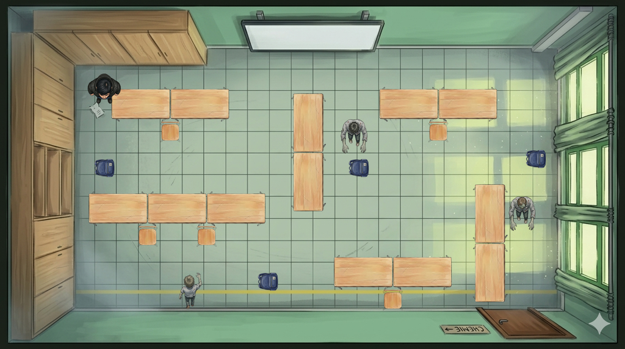

Labyrinth-Skizze

Öffne Claude Code im Projektordner `zombie-battle-royale` und paste diesen Prompt:

```
Ich baue ein Browser-Spiel (Vanilla JS, kein Framework).
Implementiere die Funktion startLabyrinth(onWin, onLose) in game/03_klassenraum/labyrinth.js.
Die Datei existiert schon als Stub — ersetze den Inhalt vollständig.

Das Minispiel läuft im Element #combat-area (1280x720px, position: relative).
Hintergrundbild: renderSceneImage("03_klassenraum/assets/klassenraum_kampf.png") — diese Funktion existiert in engine.js.

Spielmechanik — Kachel-Labyrinth (Top-down):
- Grid: 10 Spalten × 7 Zeilen. Kachelgröße: 128×100px (passt auf 1280x700px).
- Wände (Tische): tisch.png aus 03_klassenraum/assets/, skaliert auf eine Kachel.
- Spieler: ove_von_oben.png aus 03_klassenraum/assets/, startet auf Kachel (0,0) oben links.
- Ausgang: Kachel (9,6) unten rechts — markiert mit einem grünen Rahmen oder Pfeil-Div.
- 3 Zombies (zombie_oben_01/02/03.png aus 03_klassenraum/assets/) patrouillieren auf festen Routen:
  Zombie 1: bewegt sich horizontal auf Zeile 2 (links↔rechts, Schritt alle 900ms)
  Zombie 2: bewegt sich vertikal auf Spalte 5 (hoch↔runter, Schritt alle 1100ms)
  Zombie 3: bewegt sich horizontal auf Zeile 5 (links↔rechts, Schritt alle 800ms)
- Wand-Layout: Zeilen 1,3,5 haben abwechselnde Wand-Blöcke (Spalten 1,3,5,7 = Wand, Rest frei) — Zombie-Routen müssen auf freien Feldern liegen.
- Spieler bewegt sich mit WASD oder Pfeiltasten (ein Feld pro Tastendruck, keine Diagonale).
- Kollision Spieler↔Zombie → loseHeart(1) aus engine.js aufrufen, Spieler zurück zu (0,0).
- Spieler erreicht (9,6) → cleanup, onWin().
- Zeitlimit 30 Sekunden (nutze startTimer/stopTimer aus engine.js) — abgelaufen → cleanup, onLose().
- gameState.hearts === 0 → cleanup, onLose().

Schau dir game/05_basketballplatz/basketball.js als Muster für Aufbau und Cleanup an.
```

## 3.4 🎨 Siegbild mit Gemini generieren

> 📸 **Referenzfoto:** `docs/03_klassenraum/klassenraum2.jpg` — Außenbereich hinter dem Schulgebäude: geschwungene Fassade mit vertikalen rotbraunen Holzlamellen, Baumstamm-Sitzbank auf sandigen Boden, alte Bäume. **Lade es mit in Gemini hoch.**

> 📋 **Stil-Vorlage:** aus `docs/00_stil-vorlage.md` — immer ans Ende des Prompts, nie weglassen.

```
In the exact style of a LucasArts adventure game background:

Outdoor area directly behind a German school building during a zombie
apocalypse — based exactly on the attached reference photo. Match the setting:
- A curved school building in the background with closely spaced vertical
  dark-red/brown wooden slats as a facade, large windows behind the slats
- Tall trees in the foreground, partially obscuring the building
- A rustic log bench made of natural tree trunks in the center foreground
- Sandy, leaf-covered ground

Alex has just burst through the emergency exit — the door behind is shut.
The area looks abandoned: a dropped schoolbag near the bench, a single
zombie shambling away in the far background between the trees, not yet
aware. A moment of eerie calm.

STYLE: Stylized painterly cartoon illustration, slightly brushy textures, high contrast,
clear silhouettes, dark but vibrant palette — dominated by mossy greens, moody greys,
warm amber accents. Inspired by LucasArts adventure game backgrounds, Tim Burton,
Goosebumps book covers, Hotel Transylvania. Spooky but kid-friendly (age 10–14).

ATMOSPHERE: Overcast sky with a sickly yellow-green tint filtering through the
tree canopy. Dried autumn leaves scattered on the sandy ground. Long diagonal
shadows from the trees. Low ground fog drifting between the trunks.
The curved building glows faintly from within — something still moving inside.

TECHNICAL: 16:9 aspect ratio, 1280x720 resolution, eye-level shot from just
outside the emergency exit, sharp focus on the bench and building facade,
slight atmospheric depth-of-field on the far background.
No text, no speech bubbles, no UI overlays, no watermarks. No gore.
```

**📖 Deutsche Übersetzung zum Verstehen (nicht in Gemini eingeben!)**

```
Im exakten Stil eines LucasArts-Adventure-Hintergrundbilds:

Außenbereich direkt hinter einem deutschen Schulgebäude während einer
Zombie-Apokalypse — genau nach dem beigefügten Referenzfoto.
Schauplatz übernehmen:
- Ein geschwungenes Schulgebäude im Hintergrund mit dicht gesetzten vertikalen
  dunkelroten/braunen Holzlamellen als Fassade, Fenster dahinter sichtbar
- Hohe Bäume im Vordergrund, die das Gebäude teilweise verdecken
- Eine rustikale Sitzbank aus Baumstämmen im vorderen Bildmittelgrund
- Sandiger, laubbedeckter Boden

Alex ist gerade durch den Notausgang gebrochen — die Tür dahinter ist zu.
Der Bereich wirkt verlassen: eine liegengelassene Schultasche neben der Bank,
ein einzelner Zombie schlurft weit hinten zwischen den Bäumen, noch nicht
aufmerksam. Ein Moment gespenstiger Ruhe.

STIL: Stilisierte malerische Cartoon-Illustration, leicht pinselige Texturen,
hoher Kontrast, klare Silhouetten, dunkle aber kräftige Palette — dominiert
von moosigen Grüntönen, düsteren Grautönen, warmen Bernstein-Akzenten.

ATMOSPHÄRE: Bedeckter Himmel mit krankhaft gelbgrünem Ton durch das Blätterdach.
Trockene Herbstblätter auf dem Sandboden. Lange diagonale Schatten der Bäume.
Bodennaher Nebel zwischen den Stämmen. Das geschwungene Gebäude leuchtet schwach
von innen — da bewegt sich noch etwas.

TECHNISCH: 16:9-Seitenverhältnis, 1280x720 Auflösung, Augenhöhe direkt vor
dem Notausgang, scharfer Fokus auf Bank und Gebäudefassade, leichte
atmosphärische Tiefenunschärfe im Hintergrund.
Kein Text, keine Sprechblasen, keine UI-Overlays, keine Wasserzeichen.
Keine Gewaltdarstellung.
```

Speichere als `game/03_klassenraum/assets/klassenraum_sieg.png`.

Falls das Bild noch nicht im Spiel angezeigt wird, lass Claude Code das übernehmen:

```
In game/scenes.js bei der Szene "klassenraum_sieg":
Setze das image-Feld auf "03_klassenraum/assets/klassenraum_sieg.png".
```

## 3.5 🎙️ Sieg-Ton mit ElevenLabs

Wieder **Model = v3** und Stimme **„Commander Brake – Strict & Dominant”** — kopier diesen Text rein:

```
[sighs] [breathing heavily] Letzte Lücke — du schlüpfst durch und wirfst die Brandschutztür ins Schloss. Dahinter: die Turnhalle!
[pause] [whispering] Kletterseile. Wenn du auf ein Dach kommst, bist du weg von hier.
```

Speichere als `game/03_klassenraum/assets/klassenraum_voice_sieg.mp3`.

Dann lass Claude Code den Ton einbauen:

```
In game/scenes.js bei der Szene "klassenraum_sieg":
Füge ein audio-Feld hinzu mit Wert "03_klassenraum/assets/klassenraum_voice_sieg.mp3".
```

# Station 04 – Turnhalle (Minispiel: Seilklettern)

**Deine Aufgabe:** Die Turnhalle mit eigenem Startbild und Ton zum Leben erwecken — und dann das Seilklettern-Minispiel bauen.

## 4.1 🎨 Startbild mit Gemini generieren

> 📸 **Referenzfoto:** `docs/04_turnhalle/turnhalle1.jpg` — die echte Schulsporthalle von der erhöhten Galerie aus: Holz-Rippendecke mit T-förmigen Stahlträgern, Sportbodenmarkierungen, Tribünen an den Seiten, Anzeigetafel, hohe Fensterreihen. **Lade es mit in Gemini hoch**, damit der Schauplatz wiedererkennbar bleibt.

> 📋 **Stil-Vorlage:** aus `docs/00_stil-vorlage.md` — immer ans Ende des Prompts, nie weglassen.

```
In the exact style of a LucasArts adventure game background:

Interior of a school gymnasium during a zombie apocalypse — based exactly
on the attached reference photo. Match the architecture:
- Wide sports hall seen from an elevated gallery angle looking down and across
- Distinctive wooden slatted ceiling with T-shaped steel support beams running
  across the full width
- Long rows of high windows along both side walls
- Bleacher benches along the sides
- Sports court with painted floor markings (basketball, handball lines)
- Electronic scoreboard visible on the far wall
- A green emergency exit door at the far end

Six thick climbing ropes hang in a row from the ceiling rafters at the far
end of the hall — the key detail. High above where the ropes are attached,
a jagged hole has been broken through the roof — sickly daylight and overcast
sky visible through the opening.
Gymnastics mats and medicine balls lie scattered on the floor.
A teenage boy is sprinting toward the ropes: black hair, black hoodie, black
backpack, blue jeans, black shoes — desperate and determined. Several zombies
are chasing him from behind, uncomfortably close.

STYLE: Stylized painterly cartoon illustration, slightly brushy textures, high contrast,
clear silhouettes, dark but vibrant palette — dominated by mossy greens, moody greys,
warm amber accents. Inspired by LucasArts adventure game backgrounds, Tim Burton,
Goosebumps book covers, Hotel Transylvania. Spooky but kid-friendly (age 10–14).

ATMOSPHERE: Sickly yellow-green light filtering through the high windows. Low ground
fog drifting across the gym floor. Long diagonal shadows from the ceiling beams and
ropes. Dust motes swirling in cold shafts of light. An eerie hush — the squeak of
sneakers and distant shuffling echoing from below.

TECHNICAL: 16:9 aspect ratio, 1280x720 resolution, elevated gallery angle looking
down and across the hall, sharp focus on the ropes and floor, slight atmospheric
depth-of-field on the far wall.
No text, no speech bubbles, no UI overlays, no watermarks. No gore.
```

**📖 Deutsche Übersetzung zum Verstehen (nicht in Gemini eingeben!)**

```
Im exakten Stil eines LucasArts-Adventure-Hintergrundbilds:

Innenraum einer Schulsporthalle während einer Zombie-Apokalypse — genau nach
dem beigefügten Referenzfoto. Architektur übernehmen:
- Breite Sporthalle aus erhöhter Galerieansicht, schräg nach unten blickend
- Markante Holz-Rippendecke mit T-förmigen Stahlträgern quer über die
  gesamte Breite
- Lange Reihen hoher Fenster an beiden Seitenwänden
- Tribünenbänke an den Seiten
- Sportboden mit aufgemalten Linien (Basketball, Handball)
- Elektronische Anzeigetafel an der Stirnwand
- Grüne Notausgangstür am hinteren Ende

Sechs dicke Kletterseile hängen in einer Reihe von den Deckenträgern am
hinteren Ende der Halle — das entscheidende Detail. Hoch oben, wo die Seile
befestigt sind, ist ein zackiges Loch durch das Dach gebrochen — krankhaftes
Tageslicht und bedeckter Himmel scheinen hindurch.
Turnmatten und Medizinbälle liegen auf dem Boden verstreut.
Ein Teenager sprintet auf die Seile zu: schwarze Haare, schwarzer Hoodie,
schwarzer Rucksack, blaue Jeans, schwarze Schuhe — verzweifelt und entschlossen.
Mehrere Zombies verfolgen ihn von hinten, bedrohlich nah.

STIL: Stilisierte malerische Cartoon-Illustration, leicht pinselige Texturen,
hoher Kontrast, klare Silhouetten, dunkle aber kräftige Palette — dominiert
von moosigen Grüntönen, düsteren Grautönen, warmen Bernstein-Akzenten.

ATMOSPHÄRE: Krankhaft gelbgrünes Licht durch die hohen Fenster. Bodennaher
Nebel über dem Hallenboden. Lange diagonale Schatten von Trägern und Seilen.
Staubpartikel wirbeln in kalten Lichtstrahlen. Gespenstische Stille — nur das
Quietschen von Turnschuhen und entferntes Schlurfen von unten.

TECHNISCH: 16:9-Seitenverhältnis, 1280x720 Auflösung, erhöhte Galerieansicht
schräg nach unten, scharfer Fokus auf Seile und Boden, leichte atmosphärische
Tiefenunschärfe zur Stirnwand hin.
Kein Text, keine Sprechblasen, keine UI-Overlays, keine Wasserzeichen.
Keine Gewaltdarstellung.
```

Speichere als `game/04_turnhalle/assets/turnhalle_intro.png`.

Falls das Bild noch nicht im Spiel angezeigt wird, lass Claude Code das übernehmen:

```
In game/scenes.js bei der Szene "turnhalle_intro":
Setze das image-Feld auf "04_turnhalle/assets/turnhalle_intro.png".
```

## 4.2 🎙️ Startbildschirm-Sound mit ElevenLabs

ElevenLabs **v3** versteht **Audio-Tags** in eckigen Klammern direkt im Text — sie steuern, wie die Stimme klingt (z. B. flüsternd, schreiend, keuchend).

Geh auf elevenlabs.io, stelle **Model = v3** ein, wähle die Stimme **„Commander Brake – Strict & Dominant”** und kopier diesen Text 1:1 rein:

```
[breathing heavily] Die Turnhalle.
[pause] [whispering] Kletterseile — hängen von der Decke.
[pause] [determined] Das ist dein Weg nach oben.
[pause] [tense] Aber die Zombies haben dich schon entdeckt.
```

Speichere als `game/04_turnhalle/assets/turnhalle_voice_intro.mp3`.

Dann lass Claude Code den Ton einbauen:

```
In game/scenes.js bei der Szene "turnhalle_intro":
Füge ein audio-Feld hinzu mit Wert "04_turnhalle/assets/turnhalle_voice_intro.mp3".
Die Engine spielt das Audio dann automatisch beim ersten Aufruf ab und zeigt
einen Lautsprecher-Button neben dem Text.
```

## 4.3 🤖 Minispiel bauen mit Claude Code

Öffne Claude Code im Projektordner `zombie-battle-royale` und paste diesen Prompt:

```
Ich baue ein Browser-Spiel (Vanilla JS, kein Framework).
Erstelle die Datei game/04_turnhalle/seilklettern.js mit der Funktion startSeilklettern(onWin, onLose).

Das Minispiel läuft im Element #combat-area (1280x720px, position: relative).
Hintergrundbild: renderSceneImage("04_turnhalle/assets/turnhalle_kampf.png") — existiert in engine.js.

Wichtig zur Hintergrundgrafik: turnhalle_kampf.png zeigt die Turnhalle aus einer leicht erhöhten
Seitenperspektive. Die 6 Kletterseile sind im Bild im linken Bereich sichtbar und hängen vertikal
von der Decke. Positioniere die 6 Spiel-Seile so, dass sie optisch mit dem Hintergrundbild
übereinstimmen: gleichmäßig verteilt zwischen x=80px und x=560px (je ~96px Abstand).

Spielmechanik — vertikaler Kletterer:
- Es gibt 6 vertikale Seile nebeneinander als schmale braune Streifen (8px breit, volle Höhe),
  positioniert bei x ≈ 80, 176, 272, 368, 464, 560px (Mitte des Streifens).
- Alex (ove_turnhalle.png aus 04_turnhalle/assets/, ~60px breit) hängt am 3. Seil von links,
  startet unten (y ≈ 580px).
- Mit A/← wechselt Alex ein Seil nach links, mit D/→ ein Seil nach rechts.
  Kein Wechsel über den Rand (Seil 1 und Seil 6) hinaus.
- Alex klettert automatisch nach oben (gleichmäßig, kein Button nötig).
- Ein Fortschrittsbalken (schmaler Streifen, rechts am Rand, z. B. x=1240px) zeigt den Aufstieg
  von unten nach oben — bei 100% = Loch im Dach erreicht → onWin().
- Fallende Hindernisse (runde Divs ~40px, rot/braun = Medizinbälle) spawnen immer bei y=0
  (obere Kante des combat-area), zufällig auf einem der 6 Seile — nie relativ zu Alex' Position.
  So bleibt die Reaktionszeit immer gleich, egal wie hoch Alex schon ist.
  Die Bälle fallen nach unten und verschwinden, wenn sie den unteren Rand erreichen.
  Bei Kollision mit Alex → loseHeart(1) aus engine.js, kurze Unverwundbarkeit (300ms Flackern).
- Schwierigkeit steigt mit der Höhe: unter 33% = 2 Bälle gleichzeitig, 33–66% = 3 Bälle,
  über 66% = 4 Bälle, alle mit zunehmender Fallgeschwindigkeit.
- Fairness-Regel: Ab 90% Fortschritt (kurz vor dem Ziel) spawnen keine neuen Bälle mehr —
  bereits fallende Bälle laufen aus, dann ist der Weg frei.
- gameState.hearts === 0 → cleanup, onLose().

Danach:
1. Füge in game/index.html vor scenes.js ein: <script src="04_turnhalle/seilklettern.js"></script>
2. Ersetze in game/scenes.js beim turnhalle_intro den placeholderMinigame-Aufruf durch:
   startSeilklettern(() => showScene("turnhalle_sieg"), () => showScene("turnhalle_fail"))

Schau dir game/05_basketballplatz/basketball.js als Muster an.
```

> 📋 **Stil-Vorlage:** Die Stil-Zeilen in jedem Prompt stammen aus `docs/00_stil-vorlage.md` — nie weglassen, damit alle Bilder zusammenpassen.

## 4.4 🎨 Siegesbild mit Gemini generieren

> 📸 **Referenzfoto:** `docs/04_turnhalle/turnhalle2.jpg` — die Sporthalle aus der erhöhten Galerieansicht schräg nach unten: Holz-Rippendecke, Sportboden mit Linien, Tribünen, Anzeigetafel, runde Fenster an der Stirnwand. **Lade es mit in Gemini hoch.**

> 📋 **Stil-Vorlage:** aus `docs/00_stil-vorlage.md` — immer ans Ende des Prompts, nie weglassen.

```
In the exact style of a LucasArts adventure game background:

Interior of a school gymnasium during a zombie apocalypse — based exactly
on the attached reference photo. Match the architecture:
- Wide sports hall seen from an elevated gallery angle looking down and across
- Distinctive wooden slatted ceiling with T-shaped steel support beams
- Round windows and electronic scoreboard on the far wall
- Bleacher benches along the sides
- Sports court with painted floor markings

View from just above the jagged hole that has been broken through the roof:
the ragged edges of the hole frame the top of the image, and through it we
look down steeply into the gymnasium below.
Six thick climbing ropes hang from the ceiling rafters directly below the hole.
Several zombies are on the ropes — mid-climb, reaching upward toward the viewer,
grotesque faces tilted up, grasping hands extended. One or two more zombies
stand on the gym floor below, waiting their turn.

STYLE: Stylized painterly cartoon illustration, slightly brushy textures, high contrast,
clear silhouettes, dark but vibrant palette — dominated by mossy greens, moody greys,
warm amber accents. Inspired by LucasArts adventure game backgrounds, Tim Burton,
Goosebumps book covers, Hotel Transylvania. Spooky but kid-friendly (age 10–14).

ATMOSPHERE: Sickly yellow-green daylight pours through the jagged roof hole from above,
casting a harsh cone of light down onto the ropes and climbing zombies. Long diagonal
shadows from the beams. Low ground fog across the gym floor below. Dust and plaster
debris falling from the broken roof edge. The sense of immediate, closing danger.

TECHNICAL: 16:9 aspect ratio, 1280x720 resolution, steep top-down angle looking through
the hole into the hall below, sharp focus on the ropes and climbing zombies, slight
atmospheric depth-of-field on the gym floor in the background.
No text, no speech bubbles, no UI overlays, no watermarks. No gore.
```

**📖 Deutsche Übersetzung zum Verstehen (nicht in Gemini eingeben!)**

```
Im exakten Stil eines LucasArts-Adventure-Hintergrundbilds:

Innenraum einer Schulsporthalle während einer Zombie-Apokalypse — genau nach
dem beigefügten Referenzfoto. Architektur übernehmen:
- Breite Sporthalle aus erhöhter Galerieansicht, schräg nach unten blickend
- Markante Holz-Rippendecke mit T-förmigen Stahlträgern
- Runde Fenster und elektronische Anzeigetafel an der Stirnwand
- Tribünenbänke an den Seiten
- Sportboden mit aufgemalten Linien

Blick von knapp oberhalb des zackigen Lochs, das durch das Dach gebrochen wurde:
Die ausgefransten Ränder des Lochs rahmen den oberen Bildrand, und durch das Loch
schauen wir steil nach unten in die Sporthalle.
Sechs dicke Kletterseile hängen von den Deckenträgern direkt unterhalb des Lochs.
Mehrere Zombies sind bereits auf den Seilen — mitten im Klettern, greifen nach oben
in Richtung Betrachter, groteske Gesichter nach oben gewandt, ausgestreckte Hände.
Ein oder zwei weitere Zombies stehen auf dem Hallenboden darunter und warten.

STIL: Stilisierte malerische Cartoon-Illustration, leicht pinselige Texturen, hoher
Kontrast, klare Silhouetten, dunkle aber kräftige Palette — dominiert von moosigen
Grüntönen, düsteren Grautönen, warmen Bernstein-Akzenten.

ATMOSPHÄRE: Krankhaft gelbgrünes Tageslicht fällt durch das zackige Dachloch von oben
herein und wirft einen harten Lichtkegel auf die Seile und kletternden Zombies. Lange
diagonale Schatten von den Trägern. Bodennaher Nebel auf dem Hallenboden unten. Staub
und Putzreste rieseln von den Dachkanten. Das Gefühl unmittelbarer, nahender Gefahr.

TECHNISCH: 16:9-Seitenverhältnis, 1280x720 Auflösung, steile Aufsicht durch das Loch
in die Halle darunter, scharfer Fokus auf Seile und kletternde Zombies, leichte
atmosphärische Tiefenunschärfe auf dem Hallenboden im Hintergrund.
Kein Text, keine Sprechblasen, keine UI-Overlays, keine Wasserzeichen.
Keine Gewaltdarstellung.
```

Speichere als `game/04_turnhalle/assets/turnhalle_sieg.png`.

Dann lass Claude Code das Bild einbauen:

```
In game/scenes.js bei der Szene "turnhalle_sieg":
Setze das image-Feld auf "04_turnhalle/assets/turnhalle_sieg.png".
```

## 4.5 🎙️ Sieg-Ton mit ElevenLabs

Wieder **Model = v3** und Stimme **„Commander Brake – Strict & Dominant”**:

```
[sighs] [breathing heavily] Oben. Geschafft.
[pause] [panicked] Warte — sie klettern nach! Die Seile!
[pause] [determined] Weg vom Dach. Zum Basketballplatz — letzte Chance.
```

Speichere als `game/04_turnhalle/assets/turnhalle_voice_sieg.mp3`.

Dann lass Claude Code den Ton einbauen:

```
In game/scenes.js bei der Szene "turnhalle_sieg":
Füge ein audio-Feld hinzu mit Wert "04_turnhalle/assets/turnhalle_voice_sieg.mp3".
```

# Station 05 – Basketballplatz (Minispiel: Basketball-Ausweichen)

**Deine Aufgabe:** Ton hinzufügen, Siegesbild generieren — das Minispiel selbst ist bereits fertig und spielbar.

> ✅ **Bereits vorhanden:** - Startbild: `game/05_basketballplatz/assets/basketballplatz_intro.png` - Kampf-Hintergrundbild: `game/05_basketballplatz/assets/basketballplatz_kampf.png` - Das Minispiel selbst: `game/05_basketballplatz/basketball.js` — **Referenzimplementierung** für alle anderen Stationen!

## 5.1 🎙️ Startbildschirm-Sound mit ElevenLabs

Geh auf elevenlabs.io, stelle **Model = v3** ein, wähle die Stimme **„Commander Brake – Strict & Dominant”** und kopier diesen Text 1:1 rein:

```
[breathing heavily] Der Basketballplatz. Eingezäunt — überall Zombies am Zaun.
[pause] [determined] Aber das Dach. Mit dem Seil komm ich da rauf.
[pause] [panicked] Der Sportlehrer! Er hat mich gesehen!
```

Speichere als `game/05_basketballplatz/assets/basketball_voice_intro.mp3`.

Dann lass Claude Code den Ton einbauen:

```
In game/scenes.js bei der Szene "basketballplatz":
Füge ein audio-Feld hinzu mit Wert "05_basketballplatz/assets/basketball_voice_intro.mp3".
Die Engine spielt das Audio dann automatisch beim ersten Aufruf ab und zeigt
einen Lautsprecher-Button neben dem Text.
```

## 5.2 🤖 Minispiel anpassen mit Claude Code (optional)

Das Minispiel ist fertig — aber falls du es schwieriger machen willst:

```
In game/05_basketballplatz/basketball.js:
Mache das Minispiel schwieriger:
- Ab Sekunde 15 soll der Zombie-Sportlehrer zwei Bälle gleichzeitig werfen (mit 200ms Versatz).
- Ab Sekunde 25 sollen die Bälle 30% schneller fliegen.
- Füge einen sichtbaren Countdown-Timer im Minispiel ein (großer Text oben in der Mitte, zählt von 30 runter).
Ändere nichts am Muster der Funktion startBasketballAusweichen(onWin, onLose).
```

## 5.3 🎨 Siegesbild mit Gemini generieren

> 📸 **Referenzfoto:** `docs/05_basketballplatz/basketballplatz.jpeg` — der echte überdachte Schulbasketballplatz: geschwungene Holzträger mit weißen Membranpaneelen als Dach, Gitterzaun-Seiten, roter Gummibelag mit Linien, weiße Stahlpfosten, Bäume dahinter. **Lade es mit in Gemini hoch.**

> 📋 **Stil-Vorlage:** aus `docs/00_stil-vorlage.md` — immer ans Ende des Prompts, nie weglassen.

```
In the exact style of a LucasArts adventure game background:

Interior of a covered outdoor school basketball court during a zombie apocalypse —
based exactly on the attached reference photo. Match the architecture:
- Curved wooden roof beams with white stretched fabric membrane panels between them
- Chain-link fence walls on all sides, white steel pillars
- Red rubber sports floor with court line markings
- Trees and sky faintly visible through the fence and gaps in the roof

The zombie PE teacher has just been defeated — he lies slumped on the court floor below.
A climbing rope hangs from one of the curved roof beams, swaying slightly — just used.
Alex has made it up onto the roof structure: he sits on one of the broad curved wooden
beams near the top, looking out. No rope hole needed — the beam itself is the vantage point.

Outside the chain-link fence on every side: a dense, pressing horde of zombies,
silhouetted and grasping at the mesh. Inside the court — completely empty. Safe.

STYLE: Stylized painterly cartoon illustration, slightly brushy textures, high contrast,
clear silhouettes, dark but vibrant palette — dominated by mossy greens, moody greys,
warm amber accents. Inspired by LucasArts adventure game backgrounds, Tim Burton,
Goosebumps book covers, Hotel Transylvania. Spooky but kid-friendly (age 10–14).

ATMOSPHERE: Overcast sky with a sickly yellow-green tint visible through the fabric
panels above. Long diagonal shadows from the roof beams across the empty court below.
Low ground fog drifting along the fence line outside. Zombie silhouettes fill the
perimeter — hundreds of them, pressing, clawing — but none can get in.
A strange, eerie silence inside. One moment of unlikely safety.

TECHNICAL: 16:9 aspect ratio, 1280x720 resolution, view from slightly above court level
looking across the court and out through the fence, sharp focus on the rope, the beam
Alex sits on, and the zombie-filled fence perimeter, slight atmospheric depth-of-field
on the far background.
No text, no speech bubbles, no UI overlays, no watermarks. No gore.
```

**📖 Deutsche Übersetzung zum Verstehen (nicht in Gemini eingeben!)**

```
Im exakten Stil eines LucasArts-Adventure-Hintergrundbilds:

Innenraum eines überdachten Schulbasketballplatzes während einer Zombie-Apokalypse —
genau nach dem beigefügten Referenzfoto. Architektur übernehmen:
- Geschwungene Holzträger mit weißen gespannten Membranpaneelen als Dach
- Gitterzaun-Wände an allen Seiten, weiße Stahlpfosten
- Roter Gummibelag mit Spielfeldlinien
- Bäume und Himmel schwach durch Zaun und Dachöffnungen sichtbar

Der Zombie-Sportlehrer wurde gerade besiegt — er liegt zusammengesunken auf dem
Hallenboden. Ein Kletterseil hängt von einem der geschwungenen Dachträger, leicht
schaukelnd — gerade erst benutzt. Alex hat es auf die Dachkonstruktion geschafft:
er sitzt auf einem der breiten geschwungenen Holzträger oben, schaut hinaus.
Kein Loch im Dach nötig — der Träger selbst ist der Aussichtspunkt.

Draußen am Gitterzaun auf allen Seiten: eine dichte, drängende Zombie-Horde,
silhouettiert und greifend ans Maschendraht. Im Platz selbst — komplett leer. Sicher.

STIL: Stilisierte malerische Cartoon-Illustration, leicht pinselige Texturen,
hoher Kontrast, klare Silhouetten, dunkle aber kräftige Palette — dominiert von
moosigen Grüntönen, düsteren Grautönen, warmen Bernstein-Akzenten.

ATMOSPHÄRE: Bedeckter Himmel mit krankhaft gelbgrünem Ton durch die Membranpaneele.
Lange diagonale Schatten der Dachträger auf dem leeren Platz unten. Bodennaher Nebel
entlang der Zaunlinie draußen. Zombie-Silhouetten füllen den gesamten Zaun — Hunderte,
drängend, kratzend — aber keiner kommt rein. Gespenstische Stille im Inneren.
Ein Moment unwahrscheinlicher Sicherheit.

TECHNISCH: 16:9-Seitenverhältnis, 1280x720 Auflösung, Blick von leicht oberhalb
des Bodens quer über den Platz und durch den Zaun, scharfer Fokus auf das Seil,
den Träger auf dem Alex sitzt, und die zombie-gefüllte Zaunlinie, leichte
atmosphärische Tiefenunschärfe im fernen Hintergrund.
Kein Text, keine Sprechblasen, keine UI-Overlays, keine Wasserzeichen.
Keine Gewaltdarstellung.
```

Speichere als `game/05_basketballplatz/assets/basketballplatz_sieg.png`.

Dann lass Claude Code das Bild einbauen:

```
In game/scenes.js bei der Szene "basketballplatz_sieg":
Setze das image-Feld auf "05_basketballplatz/assets/basketballplatz_sieg.png".
```

## 5.4 🎺 Trillerpfeife des Sportlehrers — Item-Belohnung einbauen

Nach dem Sieg liegt die Pfeife des Zombie-Sportlehrers auf dem Boden. Alex nimmt sie mit — sie wird später auf dem Dach gebraucht, um den Hubschrauber herbeizurufen.

Das Item ist bereits im Spiel definiert. Lass Claude Code es verteilen:

```
In game/scenes.js bei der Szene "basketballplatz_sieg":
Füge in onEnter folgendes ein (falls noch nicht vorhanden):
  if (!hasItem("trillerpfeife")) {
      addItem(ITEMS.trillerpfeife);
      toast("📯 Trillerpfeife des Sportlehrers eingesteckt!");
  }

Die Trillerpfeife ist bereits in game/items.js definiert.
Sie erscheint im Inventar und schaltet auf dem Dach den Button
"📯 Trillerpfeife einsetzen — Hilfe rufen!" frei.
```

## 5.5 🎙️ Sieg-Ton mit ElevenLabs

Wieder **Model = v3** und Stimme **„Commander Brake – Strict & Dominant”**:

```
[sighs] [breathing heavily] Er liegt. Der Platz gehört mir.
[pause] [determined] Das Seil — ans Dach. Jetzt.
[pause] [whispering] Da oben... kein einziger. Nur die Horde draußen am Zaun.
```

Speichere als `game/05_basketballplatz/assets/basketball_voice_sieg.mp3`.

Dann lass Claude Code den Ton einbauen:

```
In game/scenes.js bei der Szene "basketballplatz_sieg":
Füge ein audio-Feld hinzu mit Wert "05_basketballplatz/assets/basketball_voice_sieg.mp3".
```

# Station 06 – Dach (Endszene: Hubschrauber)

**Deine Aufgabe:** Das große Finale — Töne vertonen, Abschluss-Video generieren und die Endszene einbauen.

> ✅ **Bereits vorhanden:** - Startbild Dach (leer): `game/06_dach/assets/dach.png` - Hubschrauber-Bild: `game/06_dach/assets/hubschrauber.png`

> 📋 **Stil-Vorlage:** Die Stil-Zeilen in jedem Prompt stammen aus `docs/00_stil-vorlage.md` — nie weglassen, damit alle Bilder zusammenpassen.

## 6.1 🎙️ Ton: Das Dach ist leer

Das Startbild ist bereits fertig. Jetzt braucht es einen Ton dazu.

Geh auf elevenlabs.io, stelle **Model = v3** ein, wähle die Stimme **„Commander Brake – Strict & Dominant”** und kopier diesen Text 1:1 rein:

```
[sighs] [breathing heavily] Aufs Dach. Du hast es wirklich geschafft.
[pause] [whispering] Unter dir die ganze Horde. Aber hier oben...
[pause] [whispering] Erstmal Ruhe.
```

Speichere als `game/06_dach/assets/dach_voice_ankunft.mp3`.

Dann lass Claude Code den Ton einbauen:

```
In game/scenes.js bei der Szene "dach":
Füge ein audio-Feld hinzu mit Wert "06_dach/assets/dach_voice_ankunft.mp3".
Die Engine spielt das Audio dann automatisch beim ersten Aufruf ab und zeigt
einen Lautsprecher-Button neben dem Text.
```

## 6.2 🎙️ Ton: Ein Hubschrauber taucht auf

Das Hubschrauber-Bild ist bereits fertig. Auch hier muss nur der Ton generiert werden.

Wieder **Model = v3** und Stimme **„Commander Brake – Strict & Dominant”**:

```
[whispering] Warte — hörst du das?
[pause] [panicked] Motorengeräusch! Aus der Ferne — es wird lauter!
[pause] [shouting] Ein Hubschrauber! Hier! Hier oben! Sie kommen!
```

Speichere als `game/06_dach/assets/dach_voice_hubschrauber.mp3`.

Dann lass Claude Code den Ton einbauen:

```
In game/scenes.js bei der Szene "dach_hubschrauber":
Füge ein audio-Feld hinzu mit Wert "06_dach/assets/dach_voice_hubschrauber.mp3".
```

## 6.3 🎬 Abschluss-Video mit Veo generieren

Für die eigentliche Endszene generieren wir ein Video — der Hubschrauber steigt auf und fliegt davon. Das Start-Frame ist bereits fertig (`hubschrauber.png`).

1. Geh auf gemini.google.com.
2. Lade `game/06_dach/assets/hubschrauber.png` hoch.
3. Wähle im Prompt-Feld die Option **„Videos”** — oder beginne deinen Prompt mit `Generate a video from this image`.

**Prompt:**

```
Generate an 8-second video from this exact reference image.
The military helicopter slowly lifts off from the white-roofed building,
rotors spinning fast with motion blur. The long ladder gets retracted as
the helicopter ascends and flies steadily away to the right, into the
foggy background. The people on the rooftop watch it leave, some turning
their heads and pointing.

Keep the exact same hand-drawn comic book illustration style, bold inked
lines, flat graphic novel colors, gritty post-apocalyptic atmosphere,
overgrown buildings and muted greenish tones. Do not change to photorealistic
or 3D — preserve the original 2D illustrated look perfectly.
Camera stays static.
```

Speichere das Video als `game/06_dach/assets/dach_ende.mp4`.

## 6.4 🎙️ Ton: Abflug

Wieder **Model = v3** und Stimme **„Commander Brake – Strict & Dominant”**:

```
[breathing heavily] Du bist drin. Die Tür fällt ins Schloss.
[pause] [whispering] Unter dir schrumpft die Schule. Die Zombies — winzig.
[pause] [determined] Du hast überlebt. Diesmal.
```

Speichere als `game/06_dach/assets/dach_voice_abflug.mp3`.

> ⚠️ **Ton-Konflikt:** Das Veo-Video hat einen eigenen Sound (Rotorgeräusch). Wenn gleichzeitig das Voice-Over läuft, überlagern sich beide. Varianten: - Video stummschalten → nur Voice-Over hörbar. - Voice-Over für Szene 3 weglassen → nur Video-Ton. - Einfach ausprobieren, was besser wirkt — Claude Code übernimmt das.